# Análisis Exploratorio, HDT 1

Ayleen Rubio 19003, Andrés Say 19705. Andreé Toledo 18439

4/2/2021

# Informe de análisis exploratorio

En este informe usted podrá leer los hallazgos de EDA, a continuación se muestra el resumen de los datos:

```
##        id           imdb_id            popularity           budget
##  Min.   :     5   Length:10866       Min.   : 0.00006   Min.   :        0
##  1st Qu.: 10596   Class :character   1st Qu.: 0.20758   1st Qu.:        0
##  Median : 20669   Mode  :character   Median : 0.38386   Median :        0
##  Mean   : 66064                      Mean   : 0.64644   Mean   : 14625701
##  3rd Qu.: 75610                      3rd Qu.: 0.71382   3rd Qu.: 15000000
##  Max.   :417859                      Max.   :32.98576   Max.   :425000000
##     revenue          original_title         cast             homepage
##  Min.   :0.000e+00   Length:10866       Length:10866       Length:10866
##  1st Qu.:0.000e+00   Class :character   Class :character   Class :character
##  Median :0.000e+00   Mode  :character   Mode  :character   Mode  :character
##  Mean   :3.982e+07
##  3rd Qu.:2.400e+07
##  Max.   :2.782e+09
##    director           tagline            keywords           overview
##  Length:10866       Length:10866       Length:10866       Length:10866
##  Class :character   Class :character   Class :character   Class :character
##  Mode  :character   Mode  :character   Mode  :character   Mode  :character
##
##
##
##     runtime         genres          production_companies release_date
##  Min.   :  0.0   Length:10866       Length:10866         Length:10866
##  1st Qu.: 90.0   Class :character   Class :character     Class :character
##  Median : 99.0   Mode  :character   Mode  :character     Mode  :character
##  Mean   :102.1
##  3rd Qu.:111.0
##  Max.   :900.0
##    vote_count      vote_average    release_year    budget_adj
##  Min.   :  10.0   Min.   :1.500   Min.   :1960   Min.   :        0
##  1st Qu.:  17.0   1st Qu.:5.400   1st Qu.:1995   1st Qu.:        0
##  Median :  38.0   Median :6.000   Median :2006   Median :        0
##  Mean   : 217.4   Mean   :5.975   Mean   :2001   Mean   : 17551040
##  3rd Qu.: 145.8   3rd Qu.:6.600   3rd Qu.:2011   3rd Qu.: 20853251
##  Max.   :9767.0   Max.   :9.200   Max.   :2015   Max.   :425000000
##   revenue_adj
##  Min.   :0.000e+00
##  1st Qu.:0.000e+00
##  Median :0.000e+00
##  Mean   :5.136e+07
##  3rd Qu.:3.370e+07
##  Max.   :2.827e+09
```

En el siguiente cuadro se muestra el tipo de dato de cada variable:

```
## 'data.frame':    10866 obs. of  21 variables:
##  $ id                  : int  135397 76341 262500 140607 168259 281957 87101 286217 211672 150540 ...
##  $ imdb_id             : chr  "tt0369610" "tt1392190" "tt2908446" "tt2488496" ...
##  $ popularity          : num  32.99 28.42 13.11 11.17 9.34 ...
##  $ budget              : int  150000000 150000000 110000000 200000000 190000000 135000000 155000000 108000000 74000000 175000000 ...
##  $ revenue             : num  1.51e+09 3.78e+08 2.95e+08 2.07e+09 1.51e+09 ...
##  $ original_title      : chr  "Jurassic World" "Mad Max: Fury Road" "Insurgent" "Star Wars: The Force Awakens" ...
##  $ cast                : chr  "Chris Pratt|Bryce Dallas Howard|Irrfan Khan|Vincent D'Onofrio|Nick Robinson" "Tom Hardy|Charlize Theron|Hugh Keays-Byrne|Nicholas Hoult|Josh Helman" "Shailene Woodley|Theo James|Kate Winslet|Ansel Elgort|Miles Teller" "Harrison Ford|Mark Hamill|Carrie Fisher|Adam Dr…
##  $ homepage            : chr  "http://www.jurassicworld.com/" "http://www.madmaxmovie.com/" "http://www.thedivergentseries.movie/#insurgent" "http://www.starwars.com/films/star-wars-episode-vii" ...
##  $ director            : chr  "Colin Trevorrow" "George Miller" "Robert Schwentke" "J.J. Abrams" ...
##  $ tagline             : chr  "The park is open." "What a Lovely Day." "One Choice Can Destroy You" "Every generation has a story." ...
##  $ keywords            : chr  "monster|dna|tyrannosaurus rex|velociraptor|island" "future|chase|post-apocalyptic|dystopia|australia" "based on novel|revolution|dystopia|sequel|dystopic future" "android|spaceship|jedi|space opera|3d" ...
##  $ overview            : chr  "Twenty-two years after the events of Jurassic Park, Isla Nublar now features a fully functioning dinosaur theme"| __truncated__ "An apocalyptic story set in the furthest reaches of our planet, in a stark desert landscape where humanity is b"| __truncated__ "Beatrice…
##  $ runtime             : int  124 120 119 136 137 156 125 141 91 94 ...
##  $ genres              : chr  "Action|Adventure|Science Fiction|Thriller" "Action|Adventure|Science Fiction|Thriller" "Adventure|Science Fiction|Thriller" "Action|Adventure|Science Fiction|Fantasy" ...
##  $ production_companies: chr  "Universal Studios|Amblin Entertainment|Legendary Pictures|Fuji Television Network|Dentsu" "Village Roadshow Pictures|Kennedy Miller Productions" "Summit Entertainment|Mandeville Films|Red Wagon Entertainment|NeoReel" "Lucasfilm|Truenorth Productions|Bad Robot" ...
##  $ release_date        : chr  "6/9/15" "5/13/15" "3/18/15" "12/15/15" ...
##  $ vote_count          : int  5562 6185 2480 5292 2947 3929 2598 4572 2893 3935 ...
##  $ vote_average        : num  6.5 7.1 6.3 7.5 7.3 7.2 5.8 7.6 6.5 8 ...
##  $ release_year        : int  2015 2015 2015 2015 2015 2015 2015 2015 2015 2015 ...
##  $ budget_adj          : num  1.38e+08 1.38e+08 1.01e+08 1.84e+08 1.75e+08 ...
##  $ revenue_adj         : num  1.39e+09 3.48e+08 2.72e+08 1.90e+09 1.39e+09 ...
```

## Prueba de normalidad para datos cuantitativos

Se han escogido las variables cuantitativas que podrían seguir una distribución normal, como lo es el presupuesto o los ingresos, ya que variables como el Id de la película no son datos relevantes para hacer un análisis estadístico.

### Prueba de normalidad para popularity:

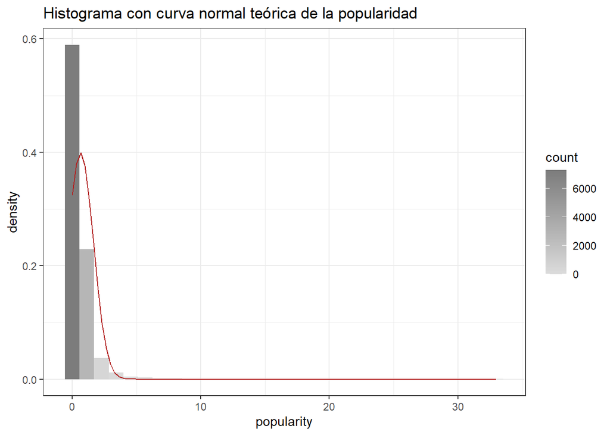

Como puede observarse, no se sigue una forma de campana y no se cuenta con simetría, por lo que no cumple con la normalidad.

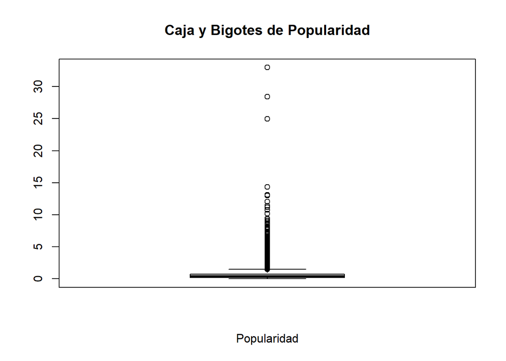

En este gráfico se observan muchos puntos atípicos y no se parece que siga una distribución normal.

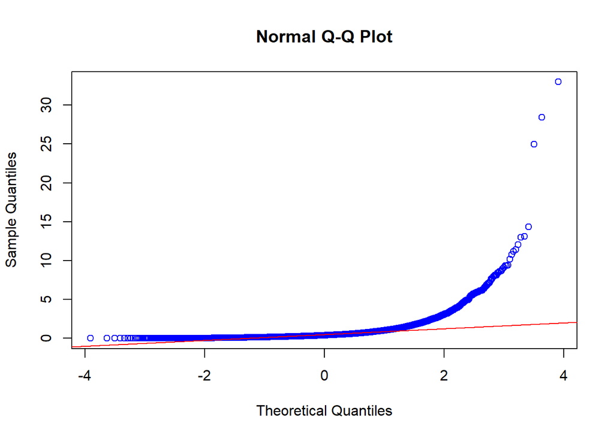

En este gráfico se puede observar que tampoco se cumple la normalidad ya que los valores no se encuentran alineados.

### Prueba de normalidad para el presupuesto:

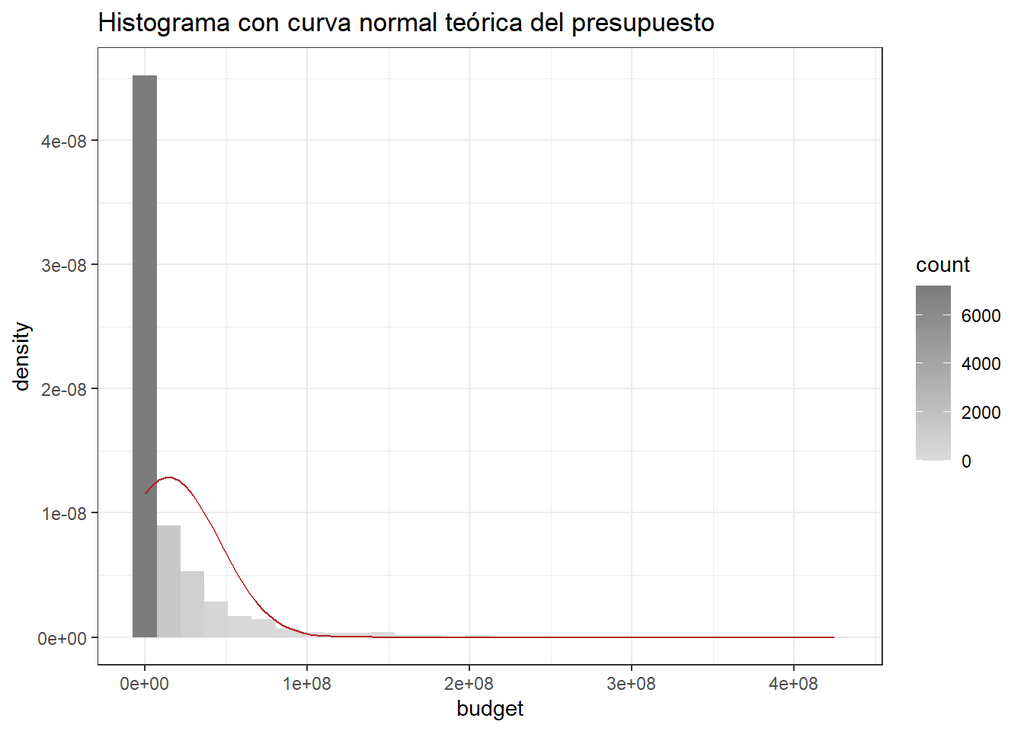

Como puede observarse, no se sigue una forma de campana y no se cuenta con simetría, por lo que no cumple con la normalidad.

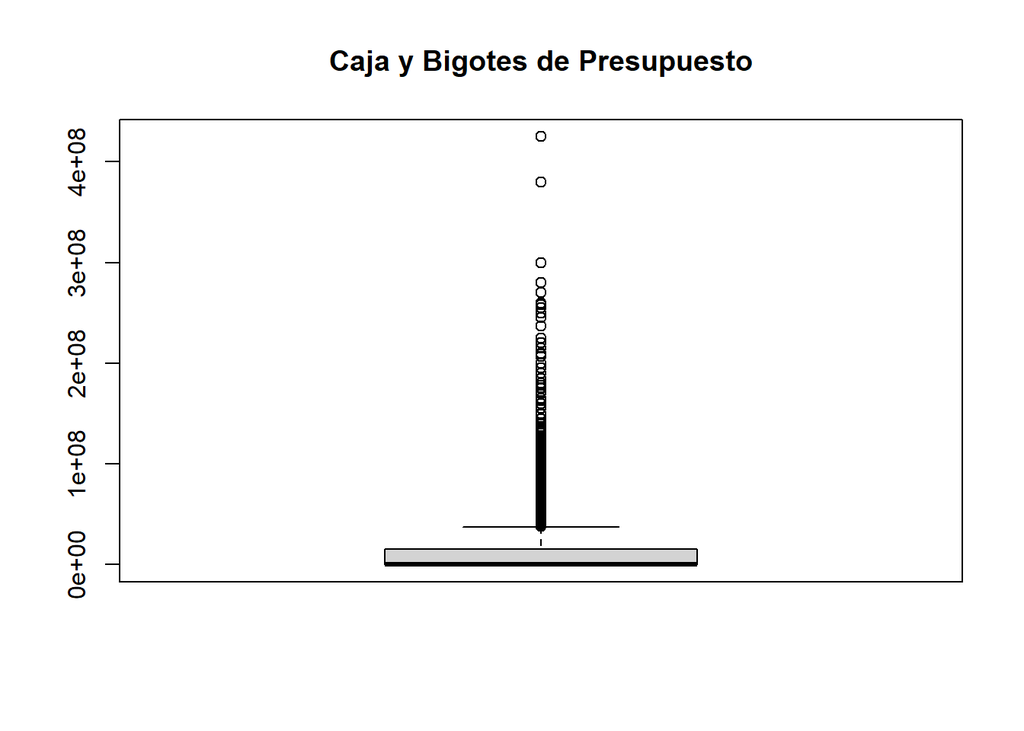

En este gráfico se observan muchos puntos atípicos y no se parece que siga una distribución normal.

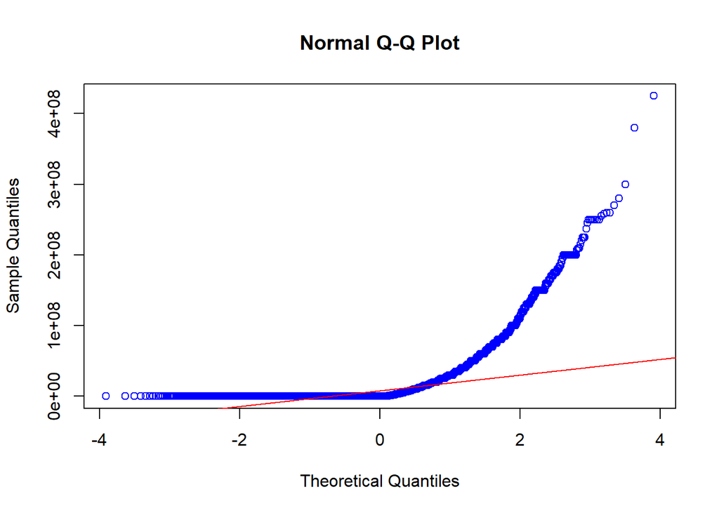

En este gráfico se puede observar que tampoco se cumple la normalidad ya que los valores no se encuentran alineados.

### Prueba de normalidad para los ingresos:

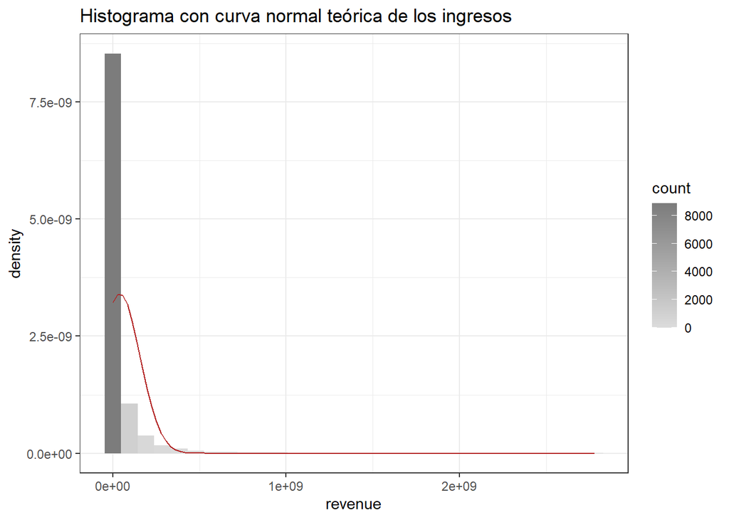

Como puede observarse, no se sigue una forma de campana y no se cuenta con simetría, por lo que no cumple con la normalidad.

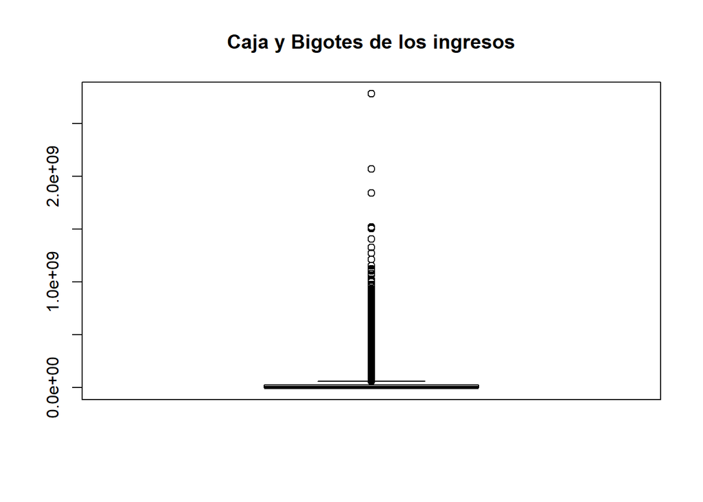

En este gráfico se observan muchos puntos atípicos y no se parece que siga una distribución normal.

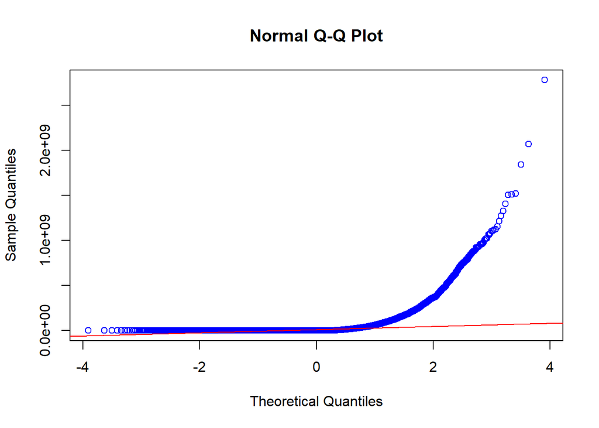

En este gráfico se puede observar que tampoco se cumple la normalidad ya que los valores no se encuentran alineados.

### Prueba de normalidad para la duración de la película:

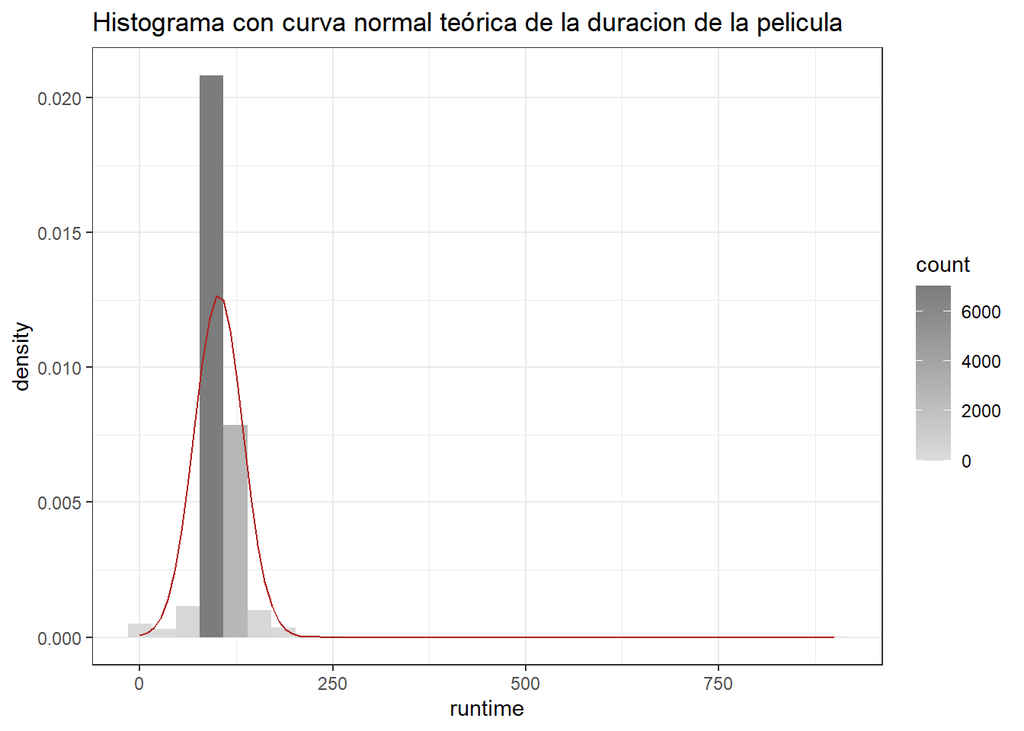

Como puede observarse, sí se sigue una forma de campana y sí se cuenta con simetría, por lo que en este caso sí se cumple con la normalidad

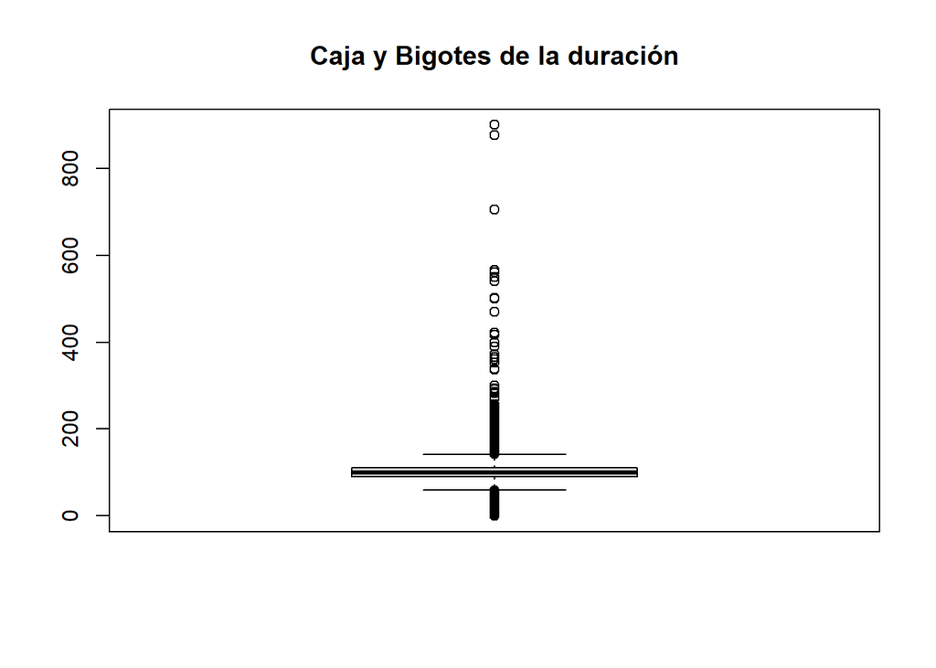

En este gráfico se observan muchos puntos atípicos y no se parece que siga una distribución normal.

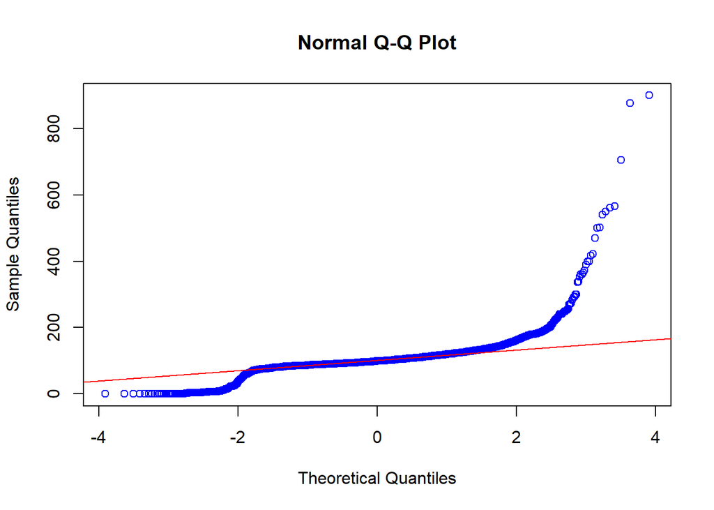

En este gráfico se puede observar que tampoco se cumple la normalidad ya que los valores no se encuentran alineados.

Debido a que dos de las tres pruebas no cumplen con normalidad, no puede afirmarse que la duración de las películas siga una distribución normal.

### Prueba de normalidad para el número de votos:

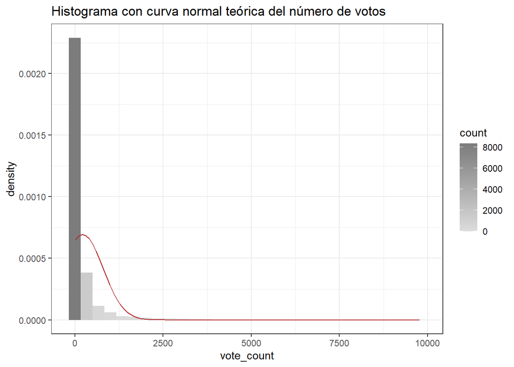

Como puede observarse, no se sigue una forma de campana y no se cuenta con simetría, por lo que no cumple con la normalidad.

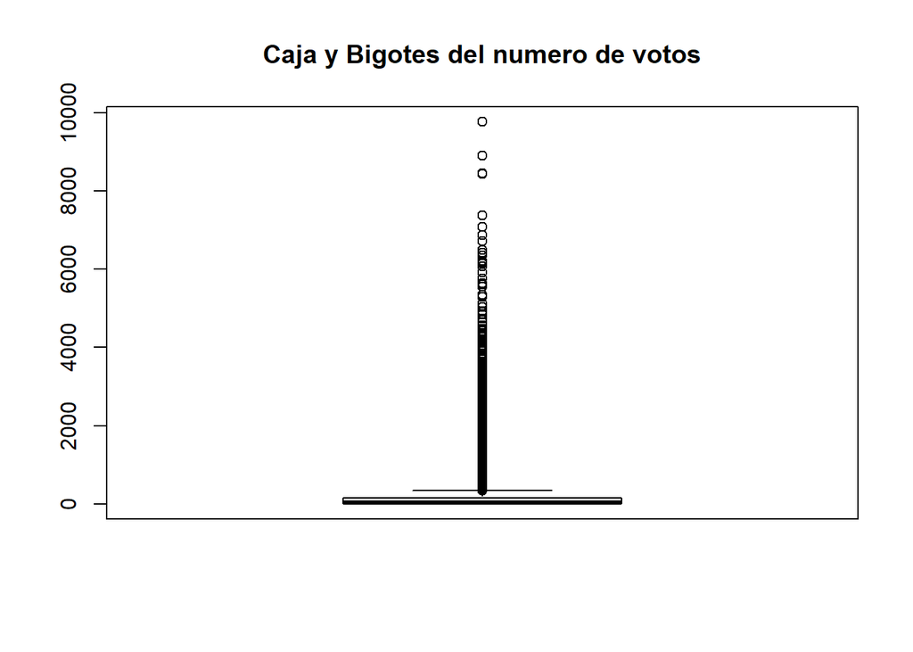

En este gráfico se observan muchos puntos atípicos y no se parece que siga una distribución normal.

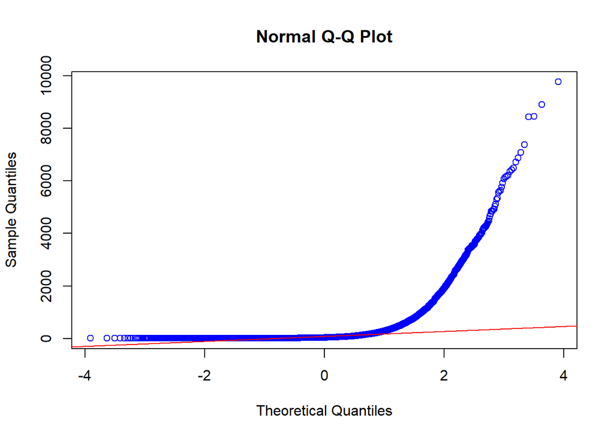

En este gráfico se puede observar que tampoco se cumple la normalidad ya que los valores no se encuentran alineados.

### Prueba de normalidad para el promedio del número de votos:

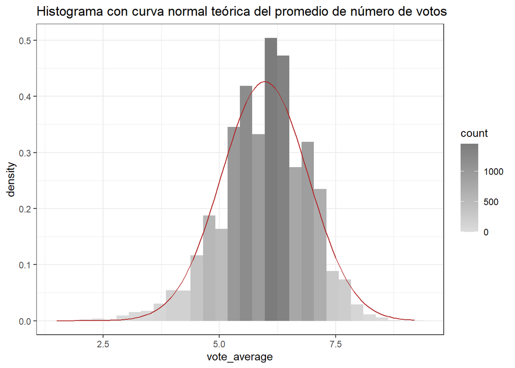

Como puede observarse, sí se sigue una forma de campana y no sí cuenta con simetría, por lo que sí cumple con la normalidad.

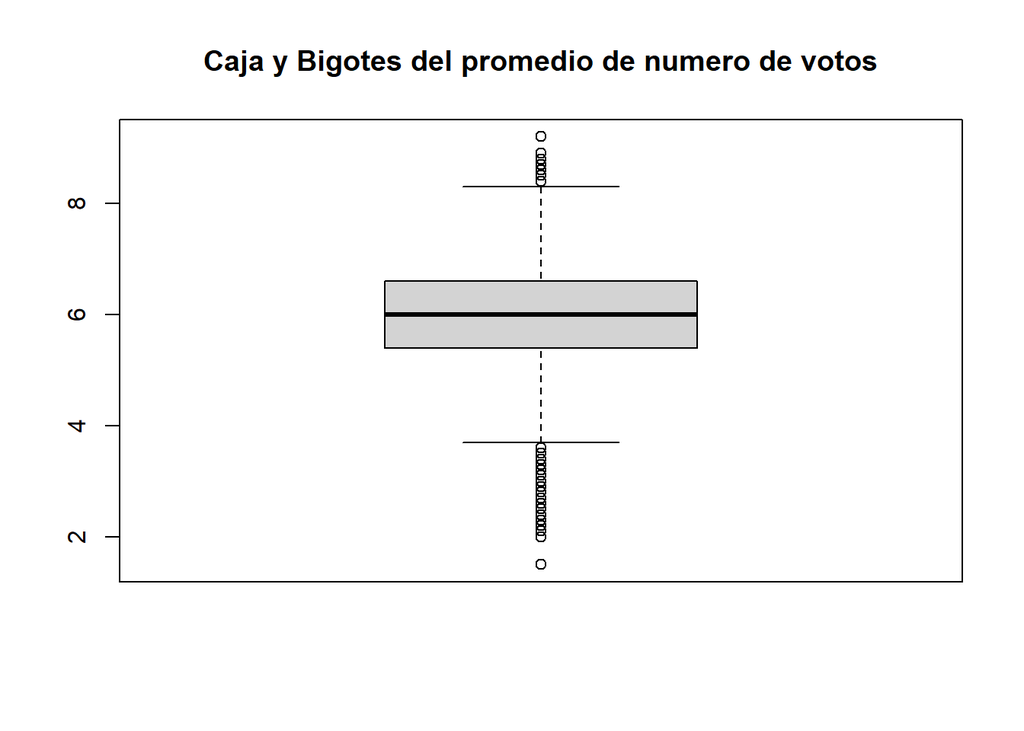

En este gráfico se observa que se sigue una distribución normal.

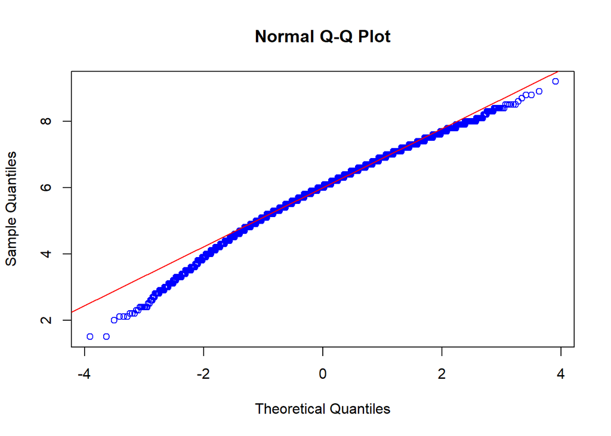

En este gráfico se puede observar que también se cumple la normalidad ya que los valores sí se encuentran alineados.

En conclusión, la única variable que sigue una distribución normal es el promedio de votos en la plataforma para las películas, esto puede ser debido a que algunas variables, como el presupuesto, ganancias y la duración, se encuentran en diferentes escalas.

## Tabla de frecuencias para variables cualitativas

### Tabla de frecuencias para los géneros

```
##                  Freq
## Var1              165 167 188 270 334 408 520 699 810 916 1230 1231 1355 1471
##   Action            0   0   0   0   0   0   0   0   0   0    0    0    0    0
##   Adventure         0   0   0   0   0   0   0   0   0   0    0    0    0    1
##   Animation         0   0   0   0   0   0   0   1   0   0    0    0    0    0
##   Comedy            0   0   0   0   0   0   0   0   0   0    0    0    0    0
##   Crime             0   0   0   0   0   0   0   0   0   0    0    0    1    0
##   Documentary       0   0   0   0   0   0   1   0   0   0    0    0    0    0
##   Drama             0   0   0   0   0   0   0   0   0   0    0    0    0    0
##   Family            0   0   0   0   0   0   0   0   0   0    0    1    0    0
##   Fantasy           0   0   0   0   0   0   0   0   0   1    0    0    0    0
##   Foreign           0   0   1   0   0   0   0   0   0   0    0    0    0    0
##   History           0   0   0   0   1   0   0   0   0   0    0    0    0    0
##   Horror            0   0   0   0   0   0   0   0   0   0    0    0    0    0
##   Music             0   0   0   0   0   1   0   0   0   0    0    0    0    0
##   Mystery           0   0   0   0   0   0   0   0   1   0    0    0    0    0
##   Romance           0   0   0   0   0   0   0   0   0   0    0    0    0    0
##   Science Fiction   0   0   0   0   0   0   0   0   0   0    1    0    0    0
##   Thriller          0   0   0   0   0   0   0   0   0   0    0    0    0    0
##   TV Movie          0   1   0   0   0   0   0   0   0   0    0    0    0    0
##   War               0   0   0   1   0   0   0   0   0   0    0    0    0    0
##   Western           1   0   0   0   0   0   0   0   0   0    0    0    0    0
##                  Freq
## Var1              1637 1712 2385 2908 3793 4761
##   Action             0    0    1    0    0    0
##   Adventure          0    0    0    0    0    0
##   Animation          0    0    0    0    0    0
##   Comedy             0    0    0    0    1    0
##   Crime              0    0    0    0    0    0
##   Documentary        0    0    0    0    0    0
##   Drama              0    0    0    0    0    1
##   Family             0    0    0    0    0    0
##   Fantasy            0    0    0    0    0    0
##   Foreign            0    0    0    0    0    0
##   History            0    0    0    0    0    0
##   Horror             1    0    0    0    0    0
##   Music              0    0    0    0    0    0
##   Mystery            0    0    0    0    0    0
##   Romance            0    1    0    0    0    0
##   Science Fiction    0    0    0    0    0    0
##   Thriller           0    0    0    1    0    0
##   TV Movie           0    0    0    0    0    0
##   War                0    0    0    0    0    0
##   Western            0    0    0    0    0    0
```

## Películas que contaron con más presupuesto

```
## resF1
##                     Avengers: Age of Ultron
##                                           1
##                                 John Carter
##                                           1
##    Pirates of the Caribbean: At World's End
##                                           1
## Pirates of the Caribbean: On Stranger Tides
##                                           1
##                                Spider-Man 3
##                                           1
##                            Superman Returns
##                                           1
##                                     Tangled
##                                           1
##                             The Lone Ranger
##                                           1
##                           The Warrior's Way
##                                           1
```

Se muestra únicamente resultados de 9 películas ya que el décimo presupuesto más alto se repite en otras 6 películas, por lo que se muestra un resultado total de 16 películas que contaron con más pesupuesto.

## Películas que contaron con más ingresos

```
## resF2
##                                       Avatar
##                                            1
##                      Avengers: Age of Ultron
##                                            1
##                                       Frozen
##                                            1
##                                    Furious 7
##                                            1
## Harry Potter and the Deathly Hallows: Part 2
##                                            1
##                                   Iron Man 3
##                                            1
##                               Jurassic World
##                                            1
##                 Star Wars: The Force Awakens
##                                            1
##                                 The Avengers
##                                            1
##                                      Titanic
##                                            1
```

## Película con más votos

```
##         id   imdb_id popularity    budget   revenue original_title
## 1920 27205 tt1375666   9.363643 160000000 825500000      Inception
##                                                                          cast
## 1920 Leonardo DiCaprio|Joseph Gordon-Levitt|Ellen Page|Tom Hardy|Ken Watanabe
##                                   homepage          director
## 1920 http://inceptionmovie.warnerbros.com/ Christopher Nolan
##                                   tagline
## 1920 Your mind is the scene of the crime.
##                                              keywords
## 1920 loss of lover|dream|sleep|subconsciousness|heist
##                                                                                                                                                                                                                                                                                      overview
## 1920 Cobb, a skilled thief who commits corporate espionage by infiltrating the subconscious of his targets is offered a chance to regain his old life as payment for a task considered to be impossible: "inception", the implantation of another person's idea into a target's subconscious.
##      runtime                                            genres
## 1920     148 Action|Thriller|Science Fiction|Mystery|Adventure
##                         production_companies release_date vote_count
## 1920 Legendary Pictures|Warner Bros.|Syncopy      7/14/10       9767
##      vote_average release_year budget_adj revenue_adj
## 1920          7.9         2010    1.6e+08   825500000
```

## Peor película de acuerdo a la cantidad de votos recibidos

```
##         id   imdb_id popularity budget revenue original_title
## 241 363689 tt4229298     0.5327      0       0   The Unspoken
##                                                                          cast
## 241 Jodelle Ferland|Sunny Suljic|Neal McDonough|Matt Bellefleur|Fulvio Cecere
##     homepage       director tagline keywords
## 241          Sheldon Wilson
##                                                                                                                                                                                                                                                                                                          …
## 241 In 1997 the close-knit Anderson family vanished from their home without a trace. No bodies were ever found and no explanation satisfied curiosity. For 17 years the house has remained undisturbed...until now. This eerily expert frightener is further enlivened by terrific performances from Ã¢â‚…
##     runtime          genres                      production_companies
## 241      90 Thriller|Horror Lighthouse Pictures|Sapphire Fire Limited
##     release_date vote_count vote_average release_year budget_adj revenue_adj
## 241     10/24/15         10          4.1         2015          0           0
```

## Año y fecha de lanzamientos

A continuación se mostrará un gráfico de barras con la cantidad de lanzamientos por año al igual que un listado de los mismos:

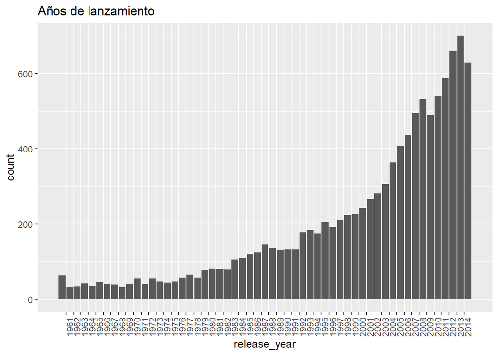

```
##    Var1 Freq
## 1  1960   32
## 2  1961   31
## 3  1962   32
## 4  1963   34
## 5  1964   42
## 6  1965   35
## 7  1966   46
## 8  1967   40
## 9  1968   39
## 10 1969   31
## 11 1970   41
## 12 1971   55
## 13 1972   40
## 14 1973   55
```

[output cut: 42 more lines]

De estos, la mayor cantidad de películas ha sido la siguiente:

```
## [1] 700
```

Lo cual, siguiendo los datos obtenidos anteriormente, corresponde al año 2014.

## Género principal de las 20 películas más populares

```
## resp6
##          Action|Adventure|Fantasy|Science Fiction
##                                                 1
##                  Action|Adventure|Science Fiction
##                                                 1
##          Action|Adventure|Science Fiction|Fantasy
##                                                 1
##         Action|Adventure|Science Fiction|Thriller
##                                                 2
##                             Action|Crime|Thriller
##                                                 1
##                  Action|Science Fiction|Adventure
##                                                 1
##                                   Action|Thriller
##                                                 1
## Action|Thriller|Science Fiction|Mystery|Adventure
##                                                 1
##                  Adventure|Action|Science Fiction
##                                                 1
##                   Adventure|Drama|Science Fiction
##                                                 1
##          Adventure|Family|Animation|Action|Comedy
##                                                 1
##                                 Adventure|Fantasy
##                                                 1
##                          Adventure|Fantasy|Action
##                                                 1
##                Adventure|Science Fiction|Thriller
##                                                 1
##                                             Drama
##                                                 1
##                       Drama|Action|Crime|Thriller
##                                                 1
##         Science Fiction|Action|Thriller|Adventure
##                                                 1
##                Science Fiction|Adventure|Thriller
##                                                 1
##                  Western|Drama|Adventure|Thriller
##                                                 1
```

El género que más predomina en el top 20 es: Acción

## Género que predomina en el conjunto de datos

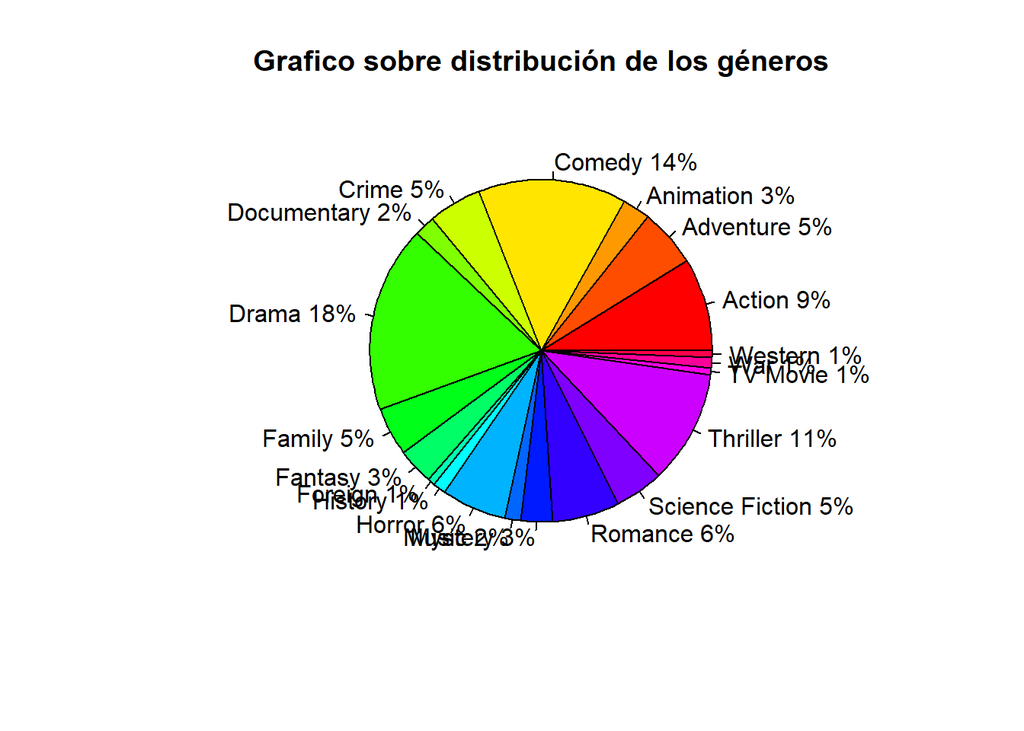

Según el gráfico observado, el género que predomina en el conjunto de datos es: Drama, representando un 18% del total.

## Películas de cierto género principal con mayores ganancias

Película : Género

2 Star Wars: The Force Awakens :Fantasy|Action|Adventure

3 Furious 7 :Action|Adventure

4 Avengers: Age of Ultron :Adventure|Fantasy|Action

5 Avatar :Adventure|Fantasy|Action|Science Fiction

6 Harry Potter and the Deathly Hallows: Part 2 :Action|Adventure|Fantasy|Science Fiction

7 The Avengers :Adventure|Action|Fantasy

8 Titanic :Adventure|Fantasy|Action|Western

9 Frozen :Animation|Family

10 Iron Man 3 :Action|Adventure|Science Fiction

## Películas de cierto género principal que necesitaron mayor presupuesto

```
Película                      :                     Género
```

1 Avengers: Age of Ultron :Adventure|Fantasy|Action

2 Tangled :Animation|Family

3 The Warrior’s Way Adventure|Fantasy|Action|Western|Thriller

4 Pirates of the Caribbean: On Stranger Tides :Action|Adventure|Fantasy|Science Fiction

5 John Carter :Adventure|Action||Thriller

6 The Lone Ranger :Action|Adventure|Western

7 Superman Returns :Action|Adventure|Science Fiction

8 Pirates of the Caribbean: At World’s End :Action|Adventure|Fantasy|Science Fiction

9 Spider-Man 3 :Action|Adventure|Science Fiction

## 20 mejores directores que hicieron películas saltamente calificadas

```
##                                                       original_title
## 3895                                   The Story of Film: An Odyssey
## 539                                             The Mask You Live In
## 1201                                   Black Mirror: White Christmas
## 2270                                                     Life Cycles
## 6912                                               Pink Floyd: Pulse
## 2402                 Opeth: In Live Concert At The Royal Albert Hall
## 3225              John Mayer: Where the Light Is Live in Los Angeles
## 3691                                               The Art of Flight
## 5831                              Doctor Who: The Time of the Doctor
## 8222 A Personal Journey with Martin Scorsese Through American Movies
## 8412                                           Queen - Rock Montreal
## 8840                             Dave Chappelle: Killin' Them Softly
## 610                    The Jinx: The Life and Deaths of Robert Durst
## 2335                                  Rush: Beyond the Lighted Stage
```

[output cut: 37 more lines]

## Correlacion entre presupuestos e ingresos

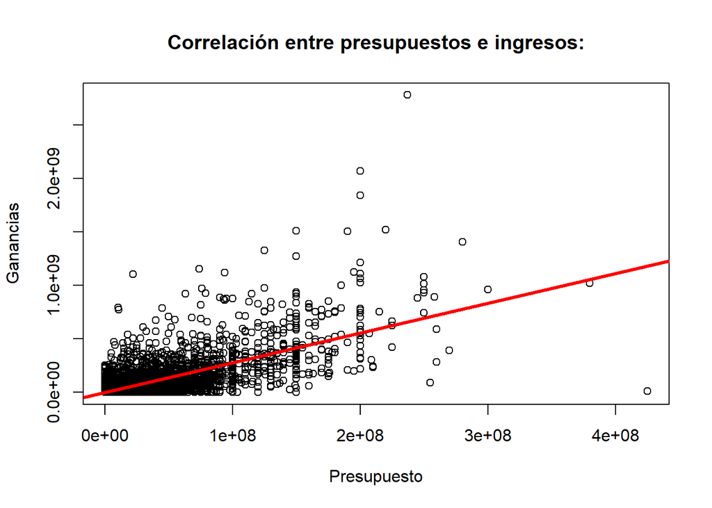

## Asociación entre meses e ingresos

```
##  [1] "6/9/15"   "12/15/15" "4/1/15"   "4/22/15"  "12/10/09" "7/7/11"
##  [7] "4/25/12"  "11/18/97" "11/27/13" "4/18/13"
```

## Meses donde hay más lanzamientos

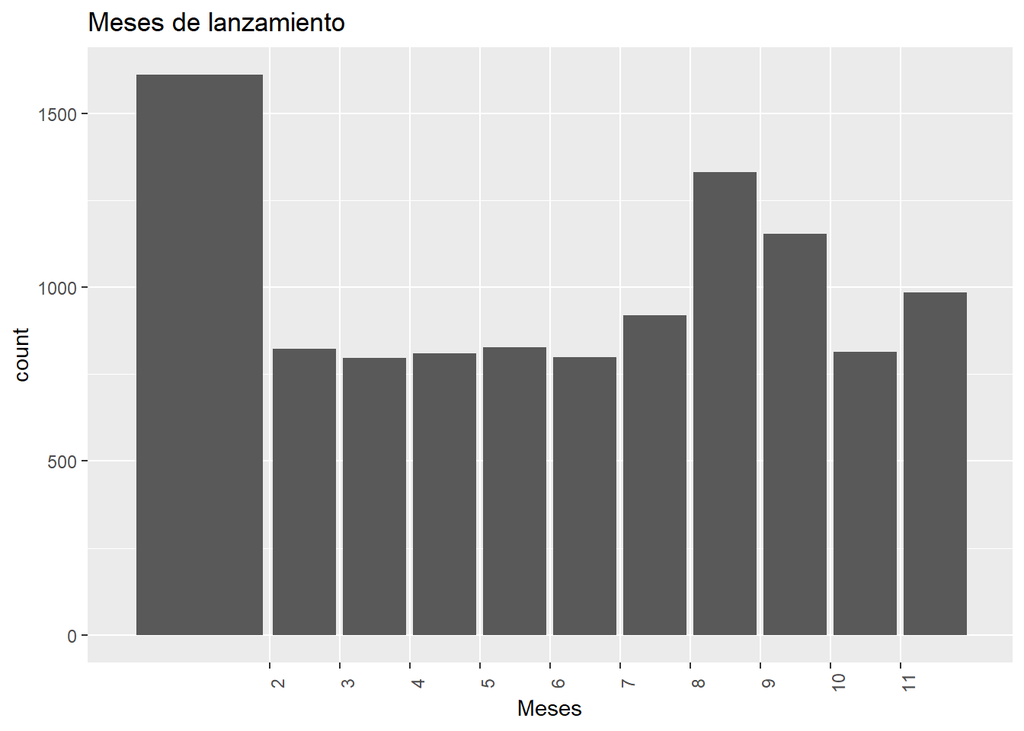

Como puede observarse, entre los meses con mayores lanzamientos se encuentran septiembre, octubre y diciembre. La barra más alta con la que se cuenta es la primera, sin embargo, esta es la unión tanto de enero como febrero, por eso se ha omitido para responder esta pregunta.

## Correlacion entre calificaciones y éxito comercial

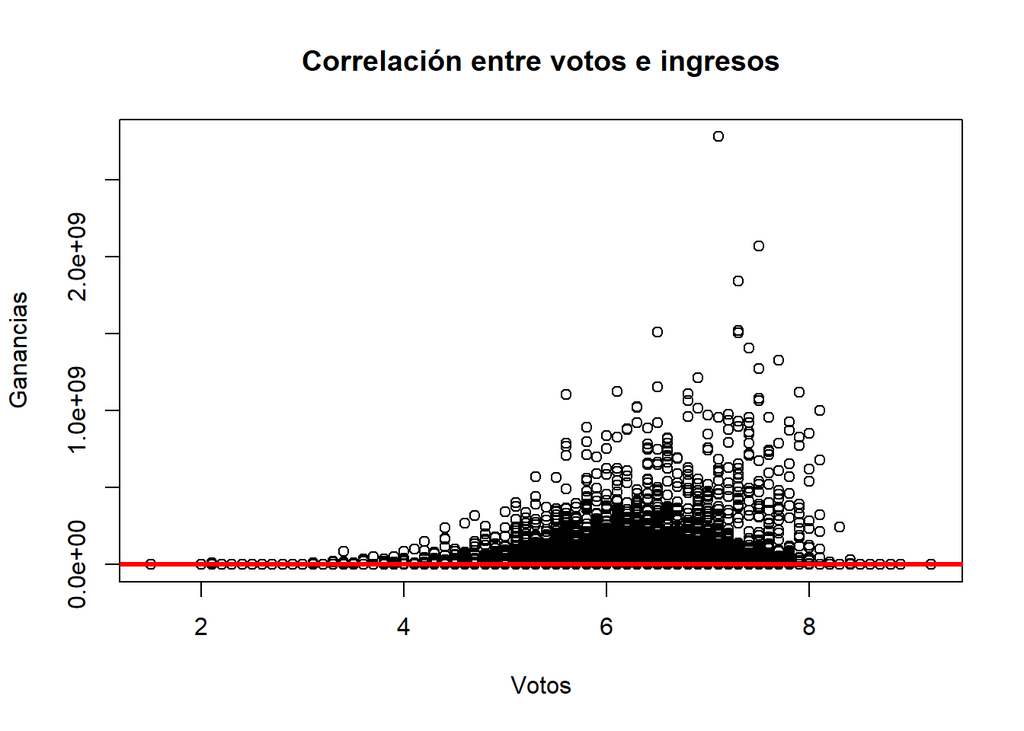

Como se puede observar en el gráfico, los datos no siguen ningún tipo de tendencia por lo que no existe correlación entre las calificaciones y el éxito comercial.

## Género de las películas con mayor duración

```
## respF15p1
## 561 566 705 877 900
##   1   1   1   1   1
```

```
## respF15p2
##      Action|Drama|War           Documentary Drama|History|Western
##                     1                     2                     1
##       Science Fiction
##                     1
```

Observando las tablas de géneros podemos determinar que los que más se repiten (en un total de 2 veces) son drama y de tipo documental